# Ánalisis de ocurrencias GBIF de Moniliophthora

Lizeth Gomez

2026-02-10

*Moniliophthora*

**a. Describa el grupo de interés y por qué es interesante. Cómo se realizó la búsqueda y los parámetros de descarga.**

Los hongos del género *Moniliophtora* que pertenecen a la familia Marasmiaceae, son conocidos principalmente por dos de sus especies que son fitopatógenas y causan estragos a nivel económico en varias regiones de America Latina.(Diaz-Valderrama & Aime 2016)

*Moniliophthora roreri:* causande de la moniliaasis del fruto infectando directamente la mazorca del cacao. *Moniliophthora perniciosa:* provoca la escoba de bruja, induce un crecimiento descontrolado de las ramas, haciendo que parezcan escobas, además de podrir los frutos.(Diaz-Valderrama & Aime 2016)

Estas enfermedades causadas por estos hongos en la mazorca del cacao los hace muy interesantes ya que han llegado a reducir significativamente la producción de cacao por lo que se ha querido encontrar estrategias para combatirle.

Cómo se realizó la búsqueda y los parámetros de descarga:

1. Entré a la página de GBIF y le dí clic en ocurrencias.
2. Escribí el nombre cientifico en este caso el género *Moniliophthora.*
3. Selecioné continente: norteamerica y suramerica.
4. Descarga simple.
5. Esperé que llegara a mi correo y lo descargué.
6. Descomprimí y extraje el archivo excel.

**b. Los comandos de linux para crear y organizar los datos**

- Entre a mi home y con **mkdir** cree la carpeta taller1 y dentro de esta cree la carpeta data:
- Entré a la carpeta data con el comando cd data y dentro de esta con el comando **wget** descargué el archivo con el link que me llegó al correo desde GBIF (este era un archivo .zip), acontinuación se muestra el proceso de descarga.

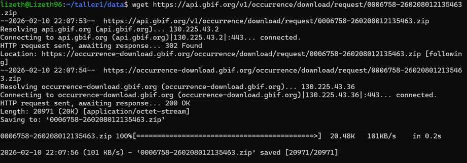

- Después de esto descomprimí el archivo .zip con el siguiente comando: **Unzip** previamente instalado.

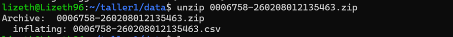

- Con el comando ls me aseguré que el archivo **.csv** estaba por fuera y con **mv** le cambié el nombre.
- Con el comando **wc -l** conté las filas del documento descargado, dando como resultado 478 lineas.

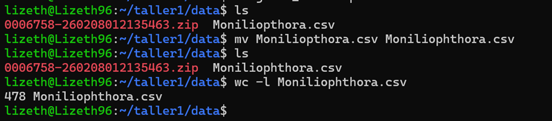

- Posteriormente cree la siguiente carpeta con **mkdir** y dentro de esta subí el (.Rmd)

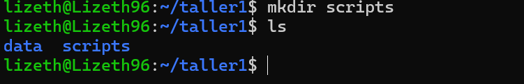

- Con el comando **/mnt/c/Users$ ls** entré a mi usuario LIDoG y con **cd** a biocompu

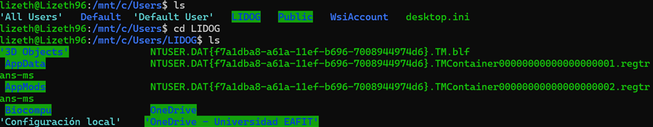

- Entré a los archivos de Biocompu y cree una copia de mi (.Rmd) con **cp** y los moví con **mv** a la carpeta destino.

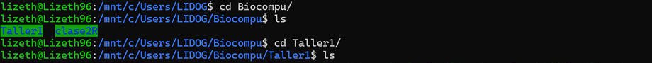

**c. Genere una gráfica con la ocurrencia de este grupo (por ejemplo un barplot) y registre los comandos utilizados.**

Acontinuación generé la gráfica:

[figure not shown]

**d. Incluya una breve interpretación del gráfico.**

**Interpretación.** En esta gráfica se puede observar que la especie con el mayor número de registros en *Moniliophthora roreri* con 336 ocurrencias seguido de *M.perniciosa*, lo que me lleva a concluir que este género esta fuertemente representado por dos patógenos principales del cacao. Esta dominancia sugiere que es la especie de mayor interés económico, investigativo y de mayor distribución geográfica en el área de estudio. Al ser el agente causante de la moniliasis del cacao, su alta frecuencia en las bases de datos refleja su impacto en la agricultura tropical.

**Referencias.**

Díaz-Valderrama, J., Aime, M. El patógeno del cacao *Moniliophthora roreri* (Marasmiaceae) posee loci de apareamiento *bialeléticos A* y *B*, pero se reproduce clonalmente. *Heredity* **116**, 491–501 (2016). https://doi.org/10.1038/hdy.2016.5

GBIF.org (10 February 2026) GBIF Occurrence Download https://doi.org/10.15468/dl.b4ufsh